# ERA_LER

Namita Joshi

n.joshi@cgiar.org

2026-09-24

# Exploring ERA

## Downloading the data

This section retrieves the most recent version of the ERA.Compiled comparisons table from the ERA S3 bucket, saves it locally, and loads it for use.

```r
# Set S3 path and initialize
s3 <- s3fs::S3FileSystem$new(anonymous = TRUE)
era_s3 <- "s3://digital-atlas/era"
bundle_dir <- file.path(era_s3, "data", "packaged")

# Get the latest bundle
all_files <- s3$dir_ls(bundle_dir)
latest_bundle <- tail(sort(grep("era_agronomy_bundle.*\\.tar\\.gz$", all_files, value = TRUE)), 1)

# Define download and extraction paths
dl_dir <- "downloaded_data"
dir.create(dl_dir, showWarnings = FALSE)
bundle_local <- file.path(dl_dir, basename(latest_bundle))
extract_dir <- file.path(dl_dir, tools::file_path_sans_ext(tools::file_path_sans_ext(basename(latest_bundle))))

# Download and extract
if (!file.exists(bundle_local)) {
  s3$file_download(latest_bundle, bundle_local, overwrite = TRUE)
}
if (!dir.exists(extract_dir)) {
  dir.create(extract_dir)
  utils::untar(bundle_local, exdir = extract_dir)
}

# Locate files
json_agronomic <- list.files(extract_dir, pattern = "^agronomic_.*\\.json$", full.names = TRUE)
json_master <- list.files(extract_dir, pattern = "^era_master_codes.*\\.json$", full.names = TRUE)
parquet_file <- list.files(extract_dir, pattern = "^era_compiled.*\\.parquet$", full.names = TRUE)

# Load into variables
ERA_Compiled <- arrow::read_parquet(parquet_file)
agronomic_metadata <- fromJSON(json_agronomic)
mastercodes <- fromJSON(json_master)
```

```r
LER<-ERA_Compiled[grepl('103',Outcode)]

# Optional: check the result
DT::datatable(
  LER,
  options = list(
    scrollY = "400px",
    scrollX = TRUE,
    pageLength = 20,
    fixedHeader = FALSE
  )
)
```

|  | Site.Key | Index | Code | Author | Date | Journal | DOI | Elevation | Country | ISO.3166.1.alpha.3 | Site.Type | Site.ID | MAT | MAP | TAP | MSP | TSP | Soil.Type | Soil.Classification | Soil.Texture | SOC | SOC.Unit | SOC.Depth | Soil.pH | Soil.pH.Method | Plant.Start | Plant.End | Harvest.Start | Harvest.End | … |
| --- | --- | --- | --- | --- | --- | --- | --- | --- | --- | --- | --- | --- | --- | --- | --- | --- | --- | --- | --- | --- | --- | --- | --- | --- | --- | --- | --- | --- | --- | --- |
| 1 | -0.4310 34.2080 B200 | 120941 | DK0117 | Midega | 2014 | FIELD CROP RES | 10.1016/j.fcr.2013.09.012 | 1200 | Kenya | KEN | Station | ICIPE, Mbita Point | 27 | 900 |  |  |  |  |  |  |  |  |  |  |  |  |  |  |  | … |
| 2 | -0.4310 34.2080 B200 | 120942 | DK0117 | Midega | 2014 | FIELD CROP RES | 10.1016/j.fcr.2013.09.012 | 1200 | Kenya | KEN | Station | ICIPE, Mbita Point | 27 | 900 |  |  |  |  |  |  |  |  |  |  |  |  |  |  |  | … |
| 3 | -0.4310 34.2080 B200 | 120943 | DK0117 | Midega | 2014 | FIELD CROP RES | 10.1016/j.fcr.2013.09.012 | 1200 | Kenya | KEN | Station | ICIPE, Mbita Point | 27 | 900 |  |  |  |  |  |  |  |  |  |  |  |  |  |  |  | … |
| 4 | -0.4310 34.2080 B200 | 120944 | DK0117 | Midega | 2014 | FIELD CROP RES | 10.1016/j.fcr.2013.09.012 | 1200 | Kenya | KEN | Station | ICIPE, Mbita Point | 27 | 900 |  |  |  |  |  |  |  |  |  |  |  |  |  |  |  | … |
| 5 | -0.4310 34.2080 B200 | 120945 | DK0117 | Midega | 2014 | FIELD CROP RES | 10.1016/j.fcr.2013.09.012 | 1200 | Kenya | KEN | Station | ICIPE, Mbita Point | 27 | 900 |  |  |  |  |  |  |  |  |  |  |  |  |  |  |  | … |
| 6 | -0.4310 34.2080 B200 | 120947 | DK0117 | Midega | 2014 | FIELD CROP RES | 10.1016/j.fcr.2013.09.012 | 1200 | Kenya | KEN | Station | ICIPE, Mbita Point | 27 | 900 |  |  |  |  |  |  |  |  |  |  |  |  |  |  |  | … |
| 7 | -0.4310 34.2080 B200 | 120948 | DK0117 | Midega | 2014 | FIELD CROP RES | 10.1016/j.fcr.2013.09.012 | 1200 | Kenya | KEN | Station | ICIPE, Mbita Point | 27 | 900 |  |  |  |  |  |  |  |  |  |  |  |  |  |  |  | … |
| 8 | -0.4310 34.2080 B200 | 120949 | DK0117 | Midega | 2014 | FIELD CROP RES | 10.1016/j.fcr.2013.09.012 | 1200 | Kenya | KEN | Station | ICIPE, Mbita Point | 27 | 900 |  |  |  |  |  |  |  |  |  |  |  |  |  |  |  | … |
| 9 | -0.4310 34.2080 B200 | 120950 | DK0117 | Midega | 2014 | FIELD CROP RES | 10.1016/j.fcr.2013.09.012 | 1200 | Kenya | KEN | Station | ICIPE, Mbita Point | 27 | 900 |  |  |  |  |  |  |  |  |  |  |  |  |  |  |  | … |
| 10 | -0.4310 34.2080 B200 | 120951 | DK0117 | Midega | 2014 | FIELD CROP RES | 10.1016/j.fcr.2013.09.012 | 1200 | Kenya | KEN | Station | ICIPE, Mbita Point | 27 | 900 |  |  |  |  |  |  |  |  |  |  |  |  |  |  |  | … |

[output cut: 743 more lines]

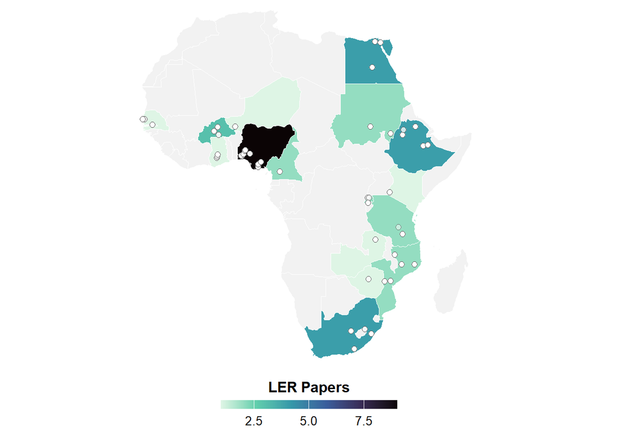

```r
LER <- LER %>%
  mutate(
    Latitude = as.numeric(Latitude),
    Longitude = as.numeric(Longitude)
  ) %>%
  filter(!is.na(Latitude) & !is.na(Longitude))

# Count the number of papers per country
paper_counts <- LER %>%
  group_by(Country) %>%
  summarise(N_Papers = n_distinct(Code), .groups = "drop")

# Load only African countries
world <- ne_countries(scale = "medium", continent = "Africa", returnclass = "sf")

# Fix Tanzania name if needed
world <- world %>%
  mutate(admin = if_else(admin == "United Republic of Tanzania", "Tanzania", admin))


# Ensure CRS is consistent
world <- st_transform(world, crs = 4326)

# Convert combined_sites to spatial data
sites_sf <- st_as_sf(LER, coords = c("Longitude", "Latitude"), crs = 4326, remove = FALSE)

# Join paper counts to map
map_data <- world %>%
  dplyr::select(admin, geometry) %>%
  rename(Country = admin) %>%
  left_join(paper_counts, by = "Country")

# Plot the map
map<- ggplot() +
  geom_sf(data = map_data, aes(fill = N_Papers), color = "white") +
  geom_point(data = sites_sf, aes(x = Longitude, y = Latitude),
             shape = 21, color = "black", fill = "white", size = 2, alpha = 0.5) +
  scale_fill_viridis_c(
    option = "mako",
    direction = -1,
    na.value = "gray95"
  ) +
  labs(fill = "LER Papers") +
  theme_minimal() +
  theme(
    legend.position = "bottom",          # ⬅ Move to bottom
    legend.direction = "horizontal",     # ⬅ Make it horizontal
    legend.title = element_text(size = 12, face = "bold"),
    legend.text = element_text(size = 10),
    axis.text = element_blank(),
    axis.ticks = element_blank(),
    axis.title = element_blank(),
    panel.grid = element_blank()
  ) +
  guides(fill = guide_colorbar(
    barwidth = 10, barheight = 0.5, title.position = "top", title.hjust = 0.5
  )) +
  coord_sf(xlim = c(-20, 55), ylim = c(-35, 38), expand = FALSE)

# Display the map
map
```

```r
unique(LER$Code)
```

```
#>  [1] "DK0117"   "AG0025"   "HK0249"   "AG0120"   "HK0300"   "NN0142"
#>  [7] "HK0233"   "EO0024"   "LM0141"   "NJ0148"   "NN0175.2" "JS0223"
#> [13] "DK0148"   "AN0076"   "AG0091"   "HK0135"   "NN0130.3" "AG0104"
#> [19] "JS0078"   "HK0043"   "EO0019"   "HK0181"   "HK0093"   "HK0041"
#> [25] "LM0066"   "NN0250"   "DK0016"   "JS0042"   "JS0164"   "JS0055"
#> [31] "NJ0075"   "AG0078"   "JS0152"   "AG0137"   "NN0058"   "JS0064"
#> [37] "AN0062"   "AG0008"   "EO0094"   "JS0116"   "AN0005"
```

We currently have 41 papers in ERA that explicitly report Land Equivalent Ratio (LER) as an outcome. However, LER can also be calculated from studies that report yield data for both crops under intercrop and monocrop conditions. For a two-crop intercrop:
$$LER = \frac{Y_{1,IC}}{Y_{1,SC}} + \frac{Y_{2,IC}}{Y_{2,SC}}$$
where $Y_{IC}$ is the yield under intercropping and $Y_{SC}$ is the yield of the same crop when grown as a sole crop. This means the evidence base can be expanded beyond the 41 studies that report LER directly, provided the necessary yield data are available.

## Calculating LER from yield data

The LER data combine four sources:

- **Reported in ERA** (`reported`): LER reported by the paper and coded as an LER outcome in ERA.
- **Reported in the raw ERA extraction** (`reported_raw`): LER reported by the paper and kept in the raw extraction, but dropped from the compiled ERA table. Only systems with a single LER value are used.
- **Calculated from yields** (`calculated_automatic`): for papers that do not report LER, LER = Σ (intercrop yield / sole-crop yield) over the component crops. Each intercrop component is matched to the sole crop of the same crop, paper, site and year, under the same experimental treatment (e.g. the same fertiliser level). A system gets an LER only if every component crop has exactly one matching sole crop; ambiguous cases are left out. The matching code is in `r_scripts/ler_matching.R`.
- **Sum of reported partial LERs** (`reported_pLER_sum`): Falconnier et al. 2016 reports only partial LERs, which are summed (grain only).

Only papers with sites in Africa are included. Watanabe 2019 (natural fallow + pearl millet) and van Asten 2011 (coffee–banana perennial system) are excluded.

All LER calculations were QC’d by Namita Joshi.

```r
source("r_scripts/ler_matching.R")
prac <- as.data.table(mastercodes$prac)
ic_codes <- prac[Practice == "Intercropping", Code]
ERA_dt <- as.data.table(ERA_Compiled)

# Papers with an intercrop arm anywhere in their yield data
yld <- ERA_dt[Outcode == "101"]
arm_cols <- c(paste0("C", 1:13), paste0("T", 1:13))
ic_papers <- unique(yld[Reduce(`|`, lapply(arm_cols, function(k) get(k) %in% ic_codes)), Code])

# Yield rows that are really LER values are excluded from the calculation
ler_coded_idx <- ler_coded_index(ERA_dt, agronomic_metadata$Data.Out)
ler_run <- calc_ler_systems(ERA_dt, ic_papers, exclude_index = ler_coded_idx)

ler_systems <- ler_run$systems
```

## Building the LER data

New rows have the same format as the reported ERA LER rows (`Units = "LER"`, `MeanC = 1`, `MeanT` = LER). Three columns are added: `LER.Source` (see above), `pLER` (the partial LERs that were summed) and `LER.QC` (notes).

```r
product_subtype <- function(crops) {
  st <- unique(ERA_dt[Product.Simple %in% crops, .(Product.Simple, Product.Subtype)])
  paste(sort(unique(st$Product.Subtype)), collapse = "-")
}

ler_exclude <- c("JO0076",   # Watanabe 2019: natural fallow + pearl millet, not an intercrop
                 "NN0311")   # van Asten 2011: coffee-banana perennial system
iso_by_paper <- rbind(unique(ERA_dt[, .(Code, iso = ISO.3166.1.alpha.3)]),
                      unique(as.data.table(agronomic_metadata$Data.Out)[!B.Code %in% ERA_dt$Code, .(Code = B.Code, iso = ISO.3166.1.alpha.3)]))
africa_papers <- iso_by_paper[!is.na(iso), .(africa = all(iso %in% world$adm0_a3)), by = Code][africa == TRUE, Code]

# Reported LER in the raw extraction that the compiled table dropped (single-valued systems only)
raw_ler <- reported_ler_from_raw(agronomic_metadata$Data.Out, agronomic_metadata$Out.Out)
compiled_103 <- unique(ERA_dt[grepl("103", Outcode), Code])
raw_rep <- raw_ler$reported[Code %in% africa_papers & !Code %in% compiled_103 & !Code %in% ler_exclude & Code != "DK0064"]
raw_rep[, paper_has_multi := any(n_values_system > 1), by = Code]
raw_rep <- raw_rep[n_values_system == 1]

# papers that report LER (compiled or raw) are not recalculated from yields
already_reported <- unique(c(compiled_103, raw_rep$Code))

in_scope <- function(dt) dt[Code %in% africa_papers & !Code %in% already_reported & !Code %in% ler_exclude]
ler_keep <- in_scope(ler_systems)[status == "OK"]
ler_comp <- in_scope(ler_run$components)[ler_keep[, .(Code, Site.ID, M.Year, sys)], on = .(Code, Site.ID, M.Year, sys)]

# 1. LER from sole + intercrop yields: one row per system, metadata from the intercrop component's ERA row
ler_new_yield <- ler_comp[, {
  tmpl <- ERA_dt[Index == as.numeric(sub(",.*$", "", ic_rows[1]))][1]
  crops <- sort(unique(Crop))
  tmpl[, `:=`(
    Index = NA, Outcode = "103", Units = "LER",
    T.Descrip = .BY$sys_, TID = paste(ic_id, collapse = "-"),
    C.Descrip = paste(mono_label, collapse = " | "), CID = paste(mono_id, collapse = "-"),
    Product = paste(crops, collapse = "-"), Product.Simple = paste(crops, collapse = "-"),
    Product.Subtype = product_subtype(crops),
    Out.SubInd = "Land Equivalent Ratio", DataLoc = "calculated",
    MeanT.Error = NA, MeanC.Error = NA, Mean.Error.Type = NA,
    MeanC = 1, MeanT = sum(pLER)
  )]
  tmpl[, `:=`(yi = log(MeanT), pc = 100 * (MeanT - 1))]
  tmpl[, `:=`(LER.Source = "calculated_automatic",
              pLER = paste0(Crop, "=", sprintf("%.3f", pLER), collapse = "; "))]
  tmpl
}, by = .(Code_ = Code, Site_ = Site.ID, Year_ = M.Year, sys_ = sys)]
ler_new_yield[, c("Code_", "Site_", "Year_", "sys_") := NULL]
ler_new_yield <- merge(ler_new_yield, ler_keep[, .(Code, Site.ID, M.Year, T.Descrip = sys, LER.QC = qc_flag)],
                       by = c("Code", "Site.ID", "M.Year", "T.Descrip"), all.x = TRUE)

# 2. Falconnier 2016 (DK0064): sum of reported grain pLERs (captured in ERA as yields)
falc <- ERA_dt[Code == "DK0064" & Outcode == "101"]
falc <- falc[grepl("-", Product.Simple) & is.na(MeanC) & !grepl("fodder", T.Descrip, ignore.case = TRUE)]
ler_new_pler <- falc[, {
  tmpl <- copy(.SD[1])
  crops <- sort(unique(unlist(strsplit(Product.Simple, "-"))))
  tmpl[, `:=`(Index = NA, Outcode = "103", Units = "LER", T.Descrip = .BY$T.Descrip_,
              Product = paste(crops, collapse = "-"), Product.Simple = paste(crops, collapse = "-"),
              Product.Subtype = product_subtype(crops),
              Out.SubInd = "Land Equivalent Ratio", DataLoc = "calculated",
              MeanT.Error = NA, MeanC.Error = NA, Mean.Error.Type = NA,
              MeanC = 1, MeanT = sum(.SD$MeanT))]
  tmpl[, `:=`(yi = log(MeanT), pc = 100 * (MeanT - 1), LER.Source = "reported_pLER_sum",
              pLER = paste(.SD$MeanT, collapse = " + "), LER.QC = NA_character_)]
  tmpl
}, by = .(T.Descrip_ = T.Descrip)][, T.Descrip_ := NULL]

# 3. Reported LER from the raw extraction: metadata from a compiled row of the same paper and site
ler_new_raw <- rbindlist(lapply(seq_len(nrow(raw_rep)), function(i) {
  r <- raw_rep[i]
  tmpl <- ERA_dt[Code == r$Code & Site.ID == r$Site.ID][1]
  if (is.na(tmpl$Code)) tmpl <- ERA_dt[Code == r$Code][1]
  tmpl <- if (is.na(tmpl$Code)) data.table(Code = r$Code) else copy(tmpl)
  prod <- gsub('..', '-', r$Product, fixed = TRUE)
  qc <- c(if (!is.na(r$LER.Group) && nzchar(r$LER.Group)) paste0('LER basis: ', r$LER.Group),
          if (r$paper_has_multi) 'paper also has multi-valued LER systems (check this is a total, not a partial LER)')
  tmpl[, `:=`(Index = NA, Outcode = '103', Out.SubInd = 'Land Equivalent Ratio', Units = 'LER',
              Site.ID = r$Site.ID, M.Year = r$M.Year,
              T.Descrip = if (!is.na(r$IN.Level.Name)) r$IN.Level.Name else r$T.Name,
              TID = NA, CID = NA, C.Descrip = NA, Product = prod, Product.Simple = prod, DataLoc = r$DataLoc,
              MeanT.Error = NA, MeanC.Error = NA, Mean.Error.Type = NA,
              MeanC = 1, MeanT = r$LER, yi = log(r$LER), pc = 100 * (r$LER - 1),
              LER.Source = 'reported_raw', pLER = NA_character_,
              LER.QC = if (length(qc)) paste(qc, collapse = '; ') else NA_character_)]
  tmpl
}), fill = TRUE)

# 4. Append to the LER data
LER_all <- rbindlist(list(
  ERA_dt[grepl("103", Outcode)][, `:=`(LER.Source = "reported", pLER = NA_character_, LER.QC = NA_character_)],
  ler_new_raw,
  ler_new_yield,
  ler_new_pler
), use.names = TRUE, fill = TRUE)

knitr::kable(LER_all[, .(rows = .N, papers = uniqueN(Code)), by = LER.Source])
```

| LER.Source | rows | papers |
| --- | --- | --- |
| reported | 753 | 41 |
| reported_raw | 604 | 44 |
| calculated_automatic | 135 | 22 |
| reported_pLER_sum | 4 | 1 |

## Updated LER evidence base

The LER data now cover 108 papers: 41 that report LER in ERA, 44 that report LER found only in the raw ERA extraction, 22 where LER was calculated from yields, and 1 where reported partial LERs were summed.

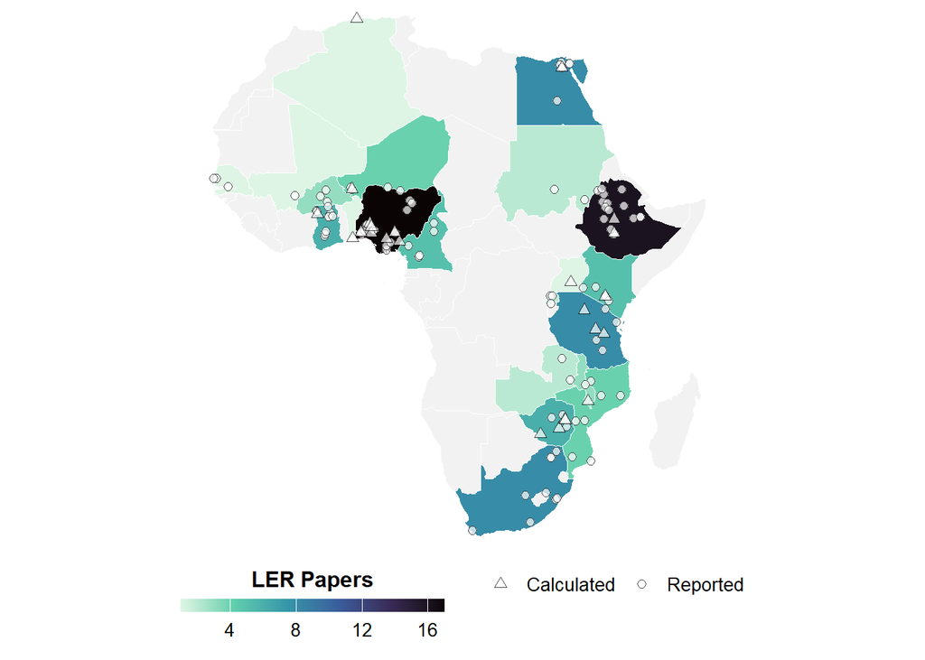

```r
LER_map <- copy(LER_all)
LER_map[, `:=`(Latitude = as.numeric(Latitude), Longitude = as.numeric(Longitude))]
LER_map[, Source := ifelse(LER.Source == "calculated_automatic", "Calculated", "Reported")]

paper_counts_all <- LER_map[, .(N_Papers = uniqueN(Code)), by = Country]

map_data_all <- world %>%
  dplyr::select(admin, geometry) %>%
  rename(Country = admin) %>%
  left_join(paper_counts_all, by = "Country")

sites_all <- unique(LER_map[!is.na(Latitude) & !is.na(Longitude), .(Code, Latitude, Longitude, Source)])

ggplot() +
  geom_sf(data = map_data_all, aes(fill = N_Papers), color = "white") +
  geom_point(data = sites_all, aes(x = Longitude, y = Latitude, shape = Source),
             color = "black", fill = "white", size = 2, alpha = 0.7) +
  scale_shape_manual(values = c(Reported = 21, Calculated = 24)) +
  scale_fill_viridis_c(option = "mako", direction = -1, na.value = "gray95") +
  labs(fill = "LER Papers", shape = NULL) +
  theme_minimal() +
  theme(
    legend.position = "bottom",
    legend.title = element_text(size = 12, face = "bold"),
    legend.text = element_text(size = 10),
    axis.text = element_blank(), axis.ticks = element_blank(),
    axis.title = element_blank(), panel.grid = element_blank()
  ) +
  guides(fill = guide_colorbar(barwidth = 10, barheight = 0.5, title.position = "top", title.hjust = 0.5)) +
  coord_sf(xlim = c(-20, 55), ylim = c(-35, 38), expand = FALSE)
```

```r
# Overall
LER_map[, .(Papers = uniqueN(Code), LER_values = .N), by = Source][, knitr::kable(.SD)]
```

| Source | Papers | LER_values |
| --- | --- | --- |
| Reported | 86 | 1361 |
| Calculated | 22 | 135 |

```r
# By country
knitr::kable(
  LER_map[, .(Papers_reported   = uniqueN(Code[Source == "Reported"]),
              Papers_calculated = uniqueN(Code[Source == "Calculated"]),
              Papers_total      = uniqueN(Code),
              LER_values        = .N), by = Country][order(-Papers_total)]
)
```

| Country | Papers_reported | Papers_calculated | Papers_total | LER_values |
| --- | --- | --- | --- | --- |
| Nigeria | 12 | 5 | 17 | 227 |
| Ethiopia | 13 | 3 | 16 | 123 |
| South Africa | 8 | 0 | 8 | 76 |
| Tanzania | 5 | 3 | 8 | 51 |
| Egypt | 7 | 1 | 8 | 112 |
| Zimbabwe | 3 | 3 | 6 | 32 |
| Ghana | 5 | 1 | 6 | 142 |
| Kenya | 4 | 1 | 5 | 174 |
| Cameroon | 5 | 0 | 5 | 93 |
| Mozambique | 4 | 0 | 4 | 155 |
| Niger | 3 | 1 | 4 | 66 |
| Burkina Faso | 3 | 0 | 3 | 81 |
| Malawi | 2 | 1 | 3 | 8 |
| NA | 3 | 0 | 3 | 32 |
| Rwanda | 2 | 0 | 2 | 48 |
| Zambia | 2 | 0 | 2 | 20 |
| Sudan | 2 | 0 | 2 | 22 |
| Gambia | 1 | 0 | 1 | 12 |
| Senegal | 1 | 0 | 1 | 12 |
| Algeria | 0 | 1 | 1 | 1 |
| Benin | 0 | 1 | 1 | 2 |
| Uganda | 0 | 1 | 1 | 3 |
| Mali | 1 | 0 | 1 | 4 |

### Save the LER data

```r
out_dir <- "outputs"
dir.create(out_dir, showWarnings = FALSE)
data.table::fwrite(LER_all, file.path(out_dir, "LER_all.csv"))                                    # reported + calculated
data.table::fwrite(LER_all[LER.Source != "reported"], file.path(out_dir, "LER_calculated_new.csv")) # new rows only
```

# What evidence do we have?

This section describes the LER data (`outputs/LER_all.csv`) by intercropping system, geography (including agro-ecological zone, AEZ) and time. Counts are of **unique papers**, because one paper can contribute many LER values. The analysis is in `r_scripts/evidence_sufficiency.R`; tables and figures are saved in `outputs/evidence_sufficiency/`.

```r
source("r_scripts/evidence_sufficiency.R")
show_fig <- function(n) knitr::include_graphics(normalizePath(file.path(es_dir, "figures", paste0(n, ".png"))), rel_path = FALSE)
```

## Intercropping systems

Crop names are standardised (`lookups/crop_type_lookup.csv`) and each crop combination is assigned to a system group (`lookups/system_group_crosswalk.csv`).

```r
knitr::kable(group_tab, caption = "System groups")
```

System groups

| system_group | combinations | papers | countries | LER_values |
| --- | --- | --- | --- | --- |
| Cereal + legume | 24 | 73 | 20 | 964 |
| Cereal + cereal | 2 | 1 | 1 | 16 |
| Root/tuber + legume | 2 | 2 | 2 | 11 |
| Root/tuber + cereal | 2 | 8 | 3 | 90 |
| Multi-crop (3+ crops) | 17 | 9 | 6 | 148 |
| Vegetable-based | 17 | 12 | 6 | 92 |
| Tree-based (agroforestry / perennial) | 15 | 7 | 5 | 99 |
| Other | 4 | 5 | 4 | 44 |
| Unidentified (single-crop label) | 5 | 4 | 3 | 32 |

```r
knitr::kable(combo_tab, caption = "Crop combinations (crop order ignored, so Maize-Cowpea and Cowpea-Maize count together)")
```

Crop combinations (crop order ignored, so Maize-Cowpea and Cowpea-Maize count together)

| combination | system_group | papers | countries | LER_values | LER_median |
| --- | --- | --- | --- | --- | --- |
| cowpea + maize | Cereal + legume | 21 | Algeria, Cameroon, Gambia, Ghana, Kenya, Mali, Mozambique, Nigeria, South Africa, Tanzania, Zambia, Zimbabwe | 225 | 1.50 |
| common bean + maize | Cereal + legume | 14 | Egypt, Ethiopia, Kenya, Malawi, South Africa, Tanzania, Uganda | 108 | 1.50 |
| maize + soybean | Cereal + legume | 9 | Cameroon, Egypt, Ethiopia, Ghana, Mozambique, Nigeria | 122 | 1.34 |
| maize + pigeon pea | Cereal + legume | 8 | Kenya, Mozambique, South Africa, Tanzania | 146 | 1.50 |
| groundnut + maize | Cereal + legume | 7 | Egypt, Ghana, Kenya, Malawi, Mozambique | 53 | 1.78 |
| cassava + maize | Root/tuber + cereal | 6 | Benin, Cameroon, Nigeria | 72 | 1.48 |
| cowpea + sorghum | Cereal + legume | 5 | Burkina Faso, Mali, Nigeria, South Africa, Zimbabwe | 33 | 1.60 |
| cowpea + pearl millet | Cereal + legume | 4 | Burkina Faso, Niger | 117 | 1.41 |
| lablab + maize | Cereal + legume | 4 | Ethiopia, South Africa, Tanzania | 17 | 1.76 |
| maize + mung bean | Cereal + legume | 3 | Egypt, Ethiopia, Kenya | 19 | 1.60 |
| maize + yam | Root/tuber + cereal | 3 | Nigeria | 18 | 1.50 |
| amaranth + maize | Vegetable-based | 2 | Nigeria | 14 | 1.14 |
| maize + okra | Vegetable-based | 2 | Cameroon | 10 | 1.62 |
| cassava + maize + watermelon | Multi-crop (3+ crops) | 2 | Nigeria | 10 | 2.04 |
| cotton + cowpea | Other | 2 | Tanzania, Zimbabwe | 8 | 1.24 |
| barley + fava bean | Cereal + legume | 2 | Ethiopia | 7 | 1.16 |
| cassava + cowpea + maize + soybean | Multi-crop (3+ crops) | 1 | Ghana | 30 | 2.09 |
| common bean + sorghum | Cereal + legume | 1 | Rwanda | 22 | 1.83 |
| sorghum + soybean | Cereal + legume | 1 | Rwanda | 22 | 1.81 |
| leucaena leucocephala + maize | Tree-based (agroforestry / perennial) | 1 | Kenya | 18 | 1.08 |
| maize + senna siamea | Tree-based (agroforestry / perennial) | 1 | Kenya | 18 | 1.33 |
| crotalaria ochrolueca + maize | Cereal + legume | 1 | Kenya | 16 | 1.60 |
| african yam bean + cassava + maize + yam | Multi-crop (3+ crops) | 1 | Nigeria | 16 | 0.44 |
| acacia senegal + sesame + sorghum | Tree-based (agroforestry / perennial) | 1 | Sudan | 16 | 1.08 |
| cotton + wheat | Other | 1 | Egypt | 16 | 2.09 |
| pearl millet + sesame | Other | 1 | Niger | 16 | 1.17 |
| african yam bean + maize + yam | Multi-crop (3+ crops) | 1 | Nigeria | 12 | 0.74 |
| african yam bean + cassava + maize | Multi-crop (3+ crops) | 1 | Nigeria | 12 | 0.66 |
| banana + coffee (arabica) | Tree-based (agroforestry / perennial) | 1 | Ethiopia | 12 | 1.50 |
| sorghum | Unidentified (single-crop label) | 1 | Ethiopia | 12 | 1.13 |

[output cut: 58 more lines]

## Geography

```r
show_fig("03a_study_locations"); show_fig("03b_country_papers")
show_fig("03d_aez_papers")
knitr::kable(region_tab, caption = "Papers by region")
```

Papers by region

| Region | countries | papers | LER_values |
| --- | --- | --- | --- |
| Eastern Africa | 9 | 48 | 632 |
| Western Africa | 8 | 36 | 560 |
| Northern Africa | 3 | 11 | 135 |
| Southern Africa | 1 | 8 | 76 |
| Middle Africa | 1 | 5 | 93 |

```r
knitr::kable(country_tab, caption = "Papers by country")
```

Papers by country

| Region | Country | papers | LER_values |
| --- | --- | --- | --- |
| Western Africa | Nigeria | 19 | 241 |
| Eastern Africa | Ethiopia | 16 | 123 |
| Southern Africa | South Africa | 8 | 76 |
| Eastern Africa | Tanzania | 8 | 51 |
| Northern Africa | Egypt | 8 | 112 |
| Eastern Africa | Kenya | 6 | 192 |
| Eastern Africa | Zimbabwe | 6 | 32 |
| Western Africa | Ghana | 6 | 142 |
| Middle Africa | Cameroon | 5 | 93 |
| Eastern Africa | Mozambique | 4 | 155 |
| Western Africa | Niger | 4 | 66 |
| Western Africa | Burkina Faso | 3 | 81 |
| Eastern Africa | Malawi | 3 | 8 |
| Eastern Africa | Rwanda | 2 | 48 |
| Eastern Africa | Zambia | 2 | 20 |
| Northern Africa | Sudan | 2 | 22 |
| Western Africa | Gambia | 1 | 12 |
| Western Africa | Senegal | 1 | 12 |
| Northern Africa | Algeria | 1 | 1 |
| Western Africa | Benin | 1 | 2 |
| Eastern Africa | Uganda | 1 | 3 |
| Western Africa | Mali | 1 | 4 |

```r
knitr::kable(aez_tab, caption = "Papers by agro-ecological zone (ERA AEZ16simple)")
```

Papers by agro-ecological zone (ERA AEZ16simple)

| AEZ | papers | countries | LER_values |
| --- | --- | --- | --- |
| warm / subhumid | 31 | 7 | 546 |
| warm / semiarid | 24 | 15 | 276 |
| cool / subhumid | 19 | 6 | 164 |
| cool / semiarid | 12 | 3 | 104 |
| warm / humid | 6 | 4 | 105 |
| cool / humid | 4 | 3 | 131 |
| warm / arid | 1 | 1 | 6 |
| Not recorded | 14 | 7 | 164 |

[figure not shown]

[figure not shown]

[figure not shown]

## System × geography

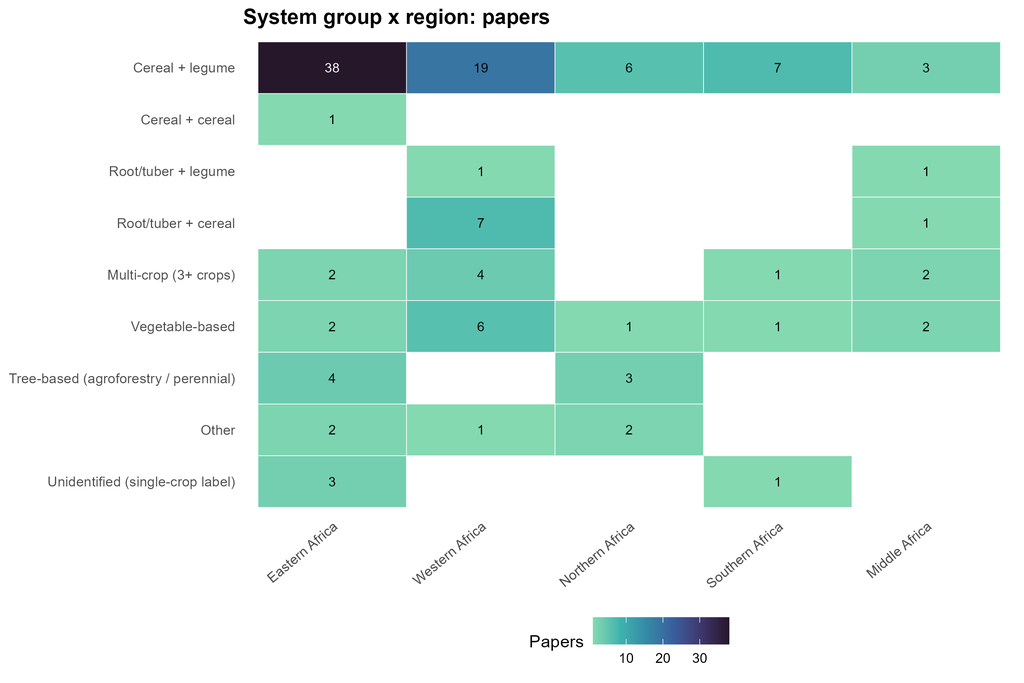

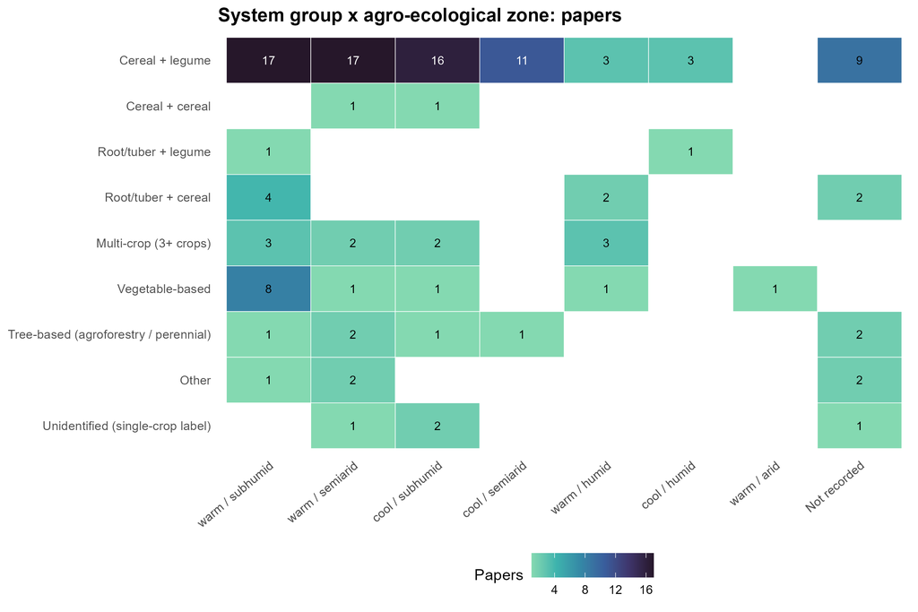

```r
show_fig("04a_system_region_papers"); show_fig("04b_system_aez_papers")
```

Cereal + legume is the only group with broad coverage (73 papers, 20 countries). The other groups are small and geographically concentrated: root/tuber + cereal is 75% Nigeria, vegetable-based systems are 50% Nigeria, tree-based systems occur only in Eastern and Northern Africa, and cereal + cereal comes from a single Kenyan paper.

## Time

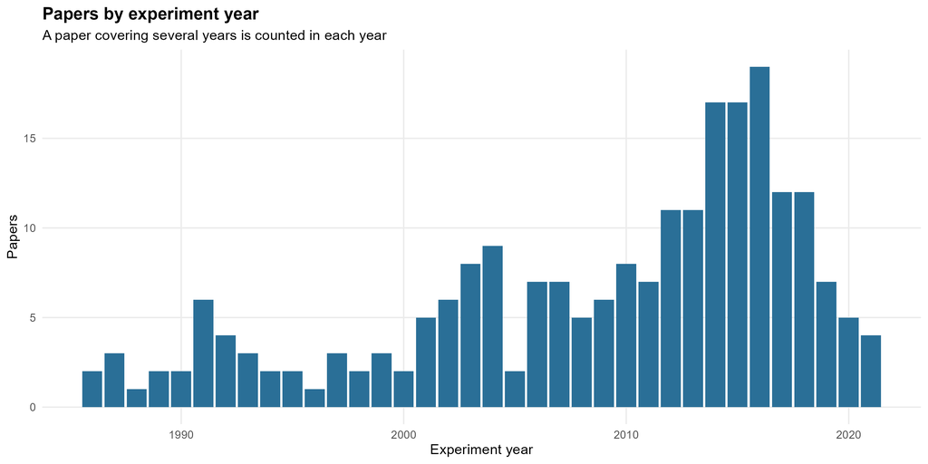

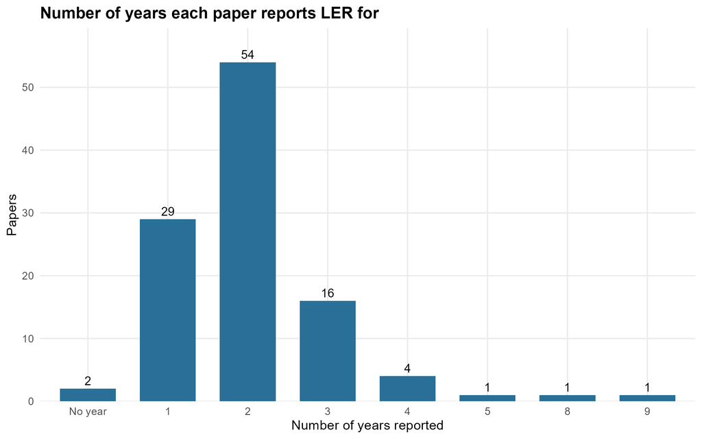

```r
show_fig("05a_papers_by_year"); show_fig("05b_years_per_paper")
```

2 papers give no calendar year for their experiments. Years averaged together in a paper are counted as years covered.

# Reassessing the research questions

| Supervisor | Suggested research direction | Evidence required | Evidence currently available | Current feasibility |
| --- | --- | --- | --- | --- |
| **Julian** | Identify **biophysical limits** to intercropping performance, e.g. drought or temperature levels beyond which LER approaches or falls below 1 | Season-specific LER, historical seasonal climate variables, and enough observations spanning mild to extreme stress | 747 season-specific cereal–legume LER observations are available; climate variables are not yet linked, so climatic coverage is unknown | **Potentially feasible; reassess after climate linkage** |
| **Julian** | Determine where empirical relationships can be **transferred spatially**, rather than extrapolating indiscriminately | Georeferenced observations, environmental covariates, and environmental similarity/novelty assessment | Coordinates are available; climate/environmental covariates still need to be linked | **Feasible once covariates are added** |
| **Julian** | Assess whether LER responses can be compared across **different intercropping systems** | Sufficient and reasonably balanced evidence across system types | Strongly dominated by cereal–legume systems; other groups are much smaller | **Not feasible across all system types; feasible within cereal–legume systems** |
| **Julian** | Explore the empirical data first to see where there is sufficient **variability, replication, and signal** before defining the final modelling approach | Clean LER dataset and evidence-structure diagnostics | Clean dataset and evidence-sufficiency analysis are available | **Feasible and already underway** |
| **Katrien** | Use the **actual weather experienced during experiments** rather than broad climate zones | Experiment year/season, location, planting period where possible, historical weather | 747 cereal–legume LER observations are season-specific; climate data still need linking | **Strongly feasible** |
| **Katrien** | Investigate whether intercropping performance differs between **dry, wet, hot, or unusual seasons** | Repeated season-specific LER linked to seasonal climate | 36 of 73 cereal–legume papers have ≥2 season-specific LERs at the same site and crop combination; 57 repeated series across ~40 locations | **Strongly feasible, provided there is enough climatic contrast** |
| **Katrien** | Keep future climate-change “what-if” questions mainly for the **crop-modelling chapter** | Calibrated crop model and future climate scenarios | Not required from this empirical dataset | **Better addressed later in the thesis** |
| **Pete** | Separate **production benefit from adaptation benefit**: does intercropping help maintain productivity or avoid losses under stress? | Actual intercrop and sole-crop yields under comparable stressful and non-stressful conditions | Repeated seasons exist, but paired yield data have not yet been audited | **Potentially feasible; requires yield-data audit** |
| **Pete** | Assess whether intercropping performs differently during **stressful versus normal seasons**, rather than relying only on average LER | Season-specific LER plus seasonal climate; ideally component yields | Season-specific LER is available; climate variables and paired yield-loss data are not yet fully assessed | **Feasible for relative LER response; uncertain for avoided-loss analysis** |
| **Pete** | Develop a more **functional description of diversification**, e.g. whether a more drought-tolerant crop is being added | Crop identity plus functional traits such as drought tolerance, rooting depth, crop duration, C3/C4 pathway | Crop identities/combinations are available; functional traits not yet compiled | **Possible secondary analysis** |
| **Pete** | Make sure the analysis can inform **where particular diversification strategies may be appropriate** | Robust system–environment relationships plus explicit applicability limits | Geographic evidence is available; environmental applicability is not yet assessed | **Potentially feasible after climate linkage** |
| **Marloes** | Judge whether there is enough evidence **within the climatic conditions of interest**, rather than relying on total sample size | Climate-linked observations distributed across relevant environmental gradients | Geographic and temporal structure is available; climate variables not yet linked | **Cannot yet assess; critical next diagnostic** |
| **Marloes** | Use this chapter to analyse **historical weather effects on intercropping**, leaving future climate-change impacts for the later modelling chapter | Historical season-specific climate linked to empirical LER observations | 747 season-specific cereal–legume LER observations are available; historical climate still needs linking | **Strongly feasible** |

# Literature review

[output not shown]